# 0) Import necessary modules

```python
import pandas as pd
import os
from tensorflow.keras.preprocessing.text import Tokenizer
import matplotlib.pyplot as plt
import seaborn as sns
import numpy as np
from tensorflow.keras.preprocessing.sequence import pad_sequences
```

```python
from tensorflow.keras.models import Sequential
from tensorflow.keras.layers import Dense
from tensorflow.keras.layers import Dropout
from tensorflow.keras.layers import Flatten
from tensorflow.keras.layers import Conv2D
from tensorflow.keras.layers import BatchNormalization
from tensorflow.keras.utils import to_categorical
from tensorflow.keras import regularizers
from keras.optimizers import Adam
from tensorflow.keras.layers import Embedding
from tensorflow.keras.preprocessing import sequence
from tensorflow.keras.layers import LSTM
```

```python
# Control gpu memory
import tensorflow as tf
gpus = tf.config.experimental.list_physical_devices('GPU')
for gpu in gpus:
  tf.config.experimental.set_memory_growth(gpu, True)
```

```python
# Set random seed for reproducibility
np.random.seed(1)
```

# 1 Background research and exploratory data analysis

```python
# Change directory
os.chdir('C:\\Users\\User\\Downloads\\CA1\\CA1')
```

```python
# Get data

movie = pd.read_csv('Movie reviews.csv')

movie
```

|  | Review | Score | Are there ways for you to generate more data? Spliting up sentences, would that help? | Language |
| --- | --- | --- | --- | --- |
| 0 | Filem ini hebat! Aksi yang mendebarkan dan plo... | 0.1 | NaN | Malay |
| 1 | Filem ini hebat! Aksi yang mendebarkan dan plo... | 0.9 | NaN | Malay |
| 2 | Filem ini hebat! Aksi yang mendebarkan dan plo... | 0.5 | NaN | Malay |
| 3 | Sayang sekali, pelakon tidak memberikan persem... | 0.8 | NaN | Malay |
| 4 | Jalan cerita yang kompleks dan penuh emosi. Su... | 0.2 | NaN | Malay |
| ... | ... | ... | ... | ... |
| 522 | Pening | 0.7 | NaN | Malay |
| 523 | Berkesan | 0.2 | NaN | Malay |
| 524 | Mengujakan | 0.1 | NaN | Malay |
| 525 | Sederhana and teruk | 0.6 | NaN | Malay |
| 526 | Sempurna | 0.1 | NaN | Malay |

527 rows × 4 columns

```python
# Check the shape of the movie data
movie.shape
```

```
(527, 4)
```

```python
# Find the types of data in each column
movie.dtypes
```

```
Review                                                                                    object
Score                                                                                    float64
Are there ways for you to generate more data? Spliting up sentences, would that help?    float64
Language                                                                                  object
dtype: object
```

```python
# See the information
movie.info()
```

```
<class 'pandas.core.frame.DataFrame'>
RangeIndex: 527 entries, 0 to 526
Data columns (total 4 columns):
 #   Column                                                                                 Non-Null Count  Dtype
---  ------                                                                                 --------------  -----
 0   Review                                                                                 527 non-null    object
 1   Score                                                                                  525 non-null    float64
 2   Are there ways for you to generate more data? Spliting up sentences, would that help?  0 non-null      float64
 3   Language                                                                               527 non-null    object
dtypes: float64(2), object(2)
memory usage: 16.6+ KB
```

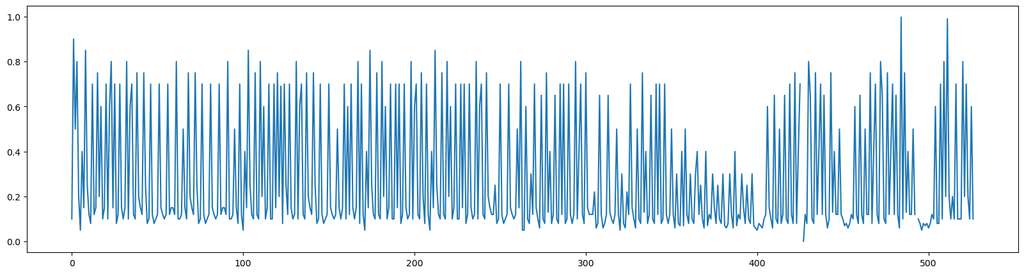

```python
# Plot the graph for score
plt.figure(figsize=(20, 5))
plt.plot(movie['Score'])
plt.show()
```

# 2 Preprocess features

```python
# Check null
movie.isnull().sum()
```

```
Review                                                                                     0
Score                                                                                      2
Are there ways for you to generate more data? Spliting up sentences, would that help?    527
Language                                                                                   0
dtype: int64
```

Since, "Are there ways for you to generate more data? Spliting up sentences, would that help?" does not help our data, remove it. Drop N.A. for score.

## a) Remove null value

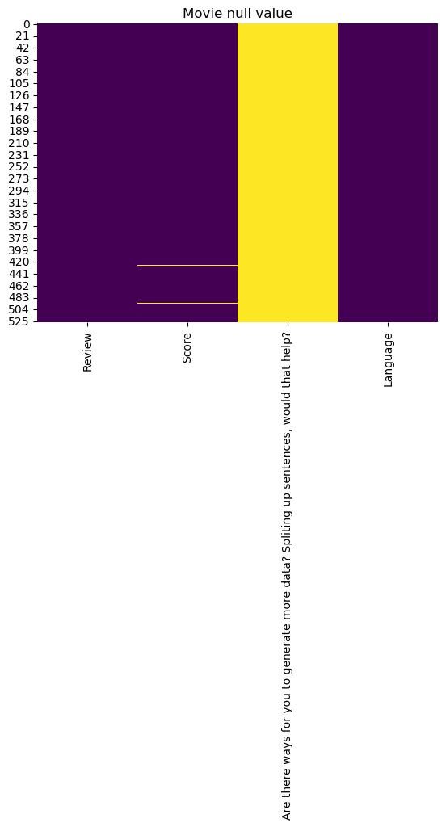

```python
# Show null value
null_df = movie.isnull()

# Plot the heatmap
sns.heatmap(null_df, cmap='viridis', cbar=False)
plt.title('Movie null value')
plt.show()
```

```python
# Drop entire rows
movie = movie.drop('Are there ways for you to generate more data? Spliting up sentences, would that help?', axis = 1)
```

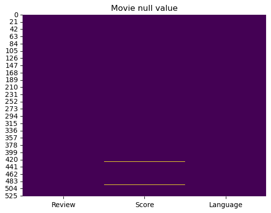

```python
# Plot the heatmap
null_df = movie.isnull()
sns.heatmap(null_df, cmap='viridis', cbar=False)
plt.title('Movie null value')
plt.show()
```

```python
# Drop rows with NA values:
movie = movie.dropna()

# Check null
movie.isnull().sum()
```

```
Review      0
Score       0
Language    0
dtype: int64
```

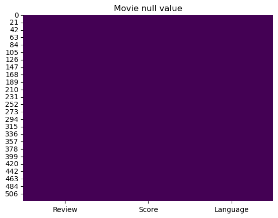

```python
# Plot the heatmap
null_df = movie.isnull()

sns.heatmap(null_df, cmap='viridis', cbar=False)
plt.title('Movie null value')
plt.show()
```

## b) Review language and which to drop

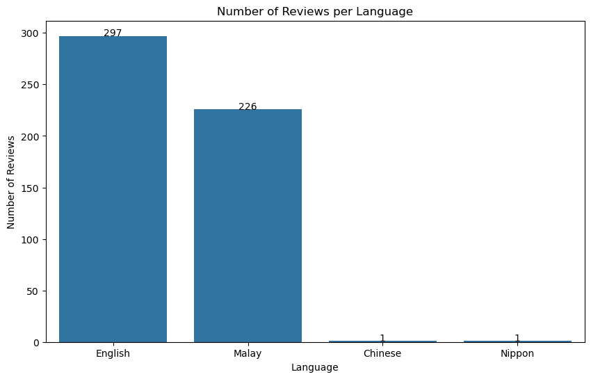

```python
# Show how many reviews are there for each languages
language = movie['Language'].value_counts().reset_index()
language.columns = ['Language', 'Count']

# Create a bar plot using Seaborn
plt.figure(figsize=(10, 6))
barplot = sns.barplot(x='Language', y='Count', data=language)

# Add annotation
for index, row in language.iterrows():
    barplot.text(row.name, row.Count, round(row.Count, 2), color='black', ha="center")


plt.title('Number of Reviews per Language')
plt.xlabel('Language')
plt.ylabel('Number of Reviews')
plt.show()
```

```python
# Remove chinese and nippon language
movie = movie[movie['Language'].isin(['English', 'Malay'])]
```

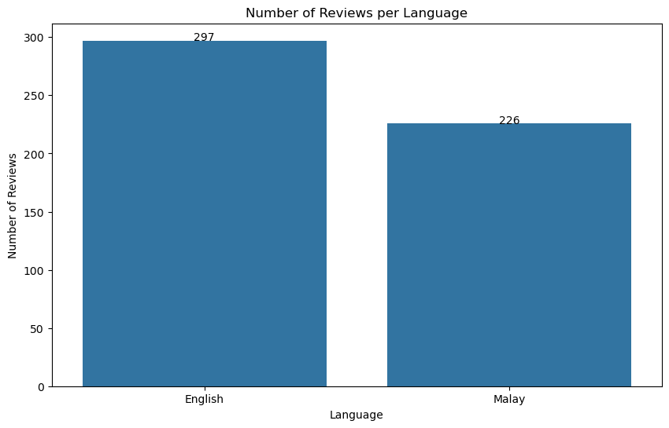

```python
# Show the graph again

language = movie['Language'].value_counts().reset_index()
language.columns = ['Language', 'Count']

# Create a bar plot using Seaborn
plt.figure(figsize=(10, 6))
barplot = sns.barplot(x='Language', y='Count', data=language)

# Show annotation
for index, row in language.iterrows():
    barplot.text(row.name, row.Count, round(row.Count, 2), color='black', ha="center")


plt.title('Number of Reviews per Language')
plt.xlabel('Language')
plt.ylabel('Number of Reviews')
plt.show()
```

## c) Remove duplicates

```python
# Check whether there is duplicate
print("Before dropping duplicate:", movie.shape)
```

```
Before dropping duplicate: (523, 3)
```

```python
# Drop duplicate
movie.drop_duplicates(inplace = True)
```

```python
# Check whether there is duplicate
print("After dropping duplicate:", movie.shape)
```

```
After dropping duplicate: (412, 3)
```

This shows that there is duplicate and need to be dropped.

```python
# Some reviews have duplicate but different scores. We want to manually check it out.
counts = movie.groupby('Review').size()
counts = counts[counts > 1]

counts
```

```
Review
Complex                                                                              2
Filem ini hebat! Aksi yang mendebarkan dan plot yang mengejutkan.                    3
Filem ini membuat saya gelak dan menangis. Suka dengan perasaan yang disampaikan.    2
Intriguing                                                                           2
Keseluruhan, filem ini hebat! Saya akan menontonnya lagi.                            2
Lack of character development makes this film weak. Not satisfying.                  2
Pelakon tidak berjaya membawa watak dengan baik. Kurang kredibel.                    2
Saya tidak suka bagaimana filem ini berakhir. Tidak memuaskan.                       2
The visual effects and animation in this film are amazing. Impressed!                2
Weak                                                                                 2
dtype: int64
```

```python
counts = counts.index.tolist()
movie[movie['Review'] == counts[0]]
```

|  | Review | Score | Language |
| --- | --- | --- | --- |
| 416 | Complex | 0.65 | English |
| 442 | Complex | 0.10 | English |

```python
# Manually remove data that does not align with the scores

for i in range(0, 10):
    print(movie[movie['Review'] == counts[i]])
    print('\n')
```

```
      Review  Score Language
416  Complex   0.65  English
442  Complex   0.10  English


                                              Review  Score Language
0  Filem ini hebat! Aksi yang mendebarkan dan plo...    0.1    Malay
1  Filem ini hebat! Aksi yang mendebarkan dan plo...    0.9    Malay
2  Filem ini hebat! Aksi yang mendebarkan dan plo...    0.5    Malay


                                                Review  Score Language
24   Filem ini membuat saya gelak dan menangis. Suk...   0.15    Malay
121  Filem ini membuat saya gelak dan menangis. Suk...   0.20    Malay


         Review  Score Language
407  Intriguing   0.15  English
446  Intriguing   0.12  English


                                                Review  Score Language
26   Keseluruhan, filem ini hebat! Saya akan menont...   0.08    Malay
125  Keseluruhan, filem ini hebat! Saya akan menont...   0.25    Malay


                                                Review  Score Language
242  Lack of character development makes this film ...   0.75  English
262  Lack of character development makes this film ...   0.80  English


                                                Review  Score Language
25   Pelakon tidak berjaya membawa watak dengan bai...   0.70    Malay
122  Pelakon tidak berjaya membawa watak dengan bai...   0.69    Malay


                                                Review  Score Language
23   Saya tidak suka bagaimana filem ini berakhir. ...   0.80    Malay
120  Saya tidak suka bagaimana filem ini berakhir. ...   0.75    Malay


                                                Review  Score Language
234  The visual effects and animation in this film ...   0.10  English
263  The visual effects and animation in this film ...   0.05  English


    Review  Score Language
422   Weak   0.75  English
448   Weak   0.50  English
```

```python
# Drop duplicates of reviews that does not align well with the score. Such as review say is "Weak" but the score is 0.5 when score should be 0.75.
rows_to_drop = [442, 1, 2, 24, 407, 125, 242, 122, 120, 234, 422]
movie = movie.drop(rows_to_drop)
```

```python
# Show there is no duplicates
counts = movie.groupby('Review').size()
counts = counts[counts > 1]
counts
```

```
Series([], dtype: int64)
```

Convert the data in movies into a list

## d) Increase data by translating

Since we do not have enough data, we would like to translate all malay language into English.

```python
movie
```

|  | Review | Score | Language |
| --- | --- | --- | --- |
| 0 | Filem ini hebat! Aksi yang mendebarkan dan plo... | 0.10 | Malay |
| 3 | Sayang sekali, pelakon tidak memberikan persem... | 0.80 | Malay |
| 4 | Jalan cerita yang kompleks dan penuh emosi. Su... | 0.20 | Malay |
| 5 | Pembuat filem berjaya memberikan pengalaman ya... | 0.05 | Malay |
| 6 | Adegan aksi yang terlalu banyak dan mengejutka... | 0.40 | Malay |
| ... | ... | ... | ... |
| 522 | Pening | 0.70 | Malay |
| 523 | Berkesan | 0.20 | Malay |
| 524 | Mengujakan | 0.10 | Malay |
| 525 | Sederhana and teruk | 0.60 | Malay |
| 526 | Sempurna | 0.10 | Malay |

401 rows × 3 columns

### Translation

```python
from googletrans import Translator

translator = Translator()

# Change malay to english
def translate_to_english(text):
    translator = Translator()
    translation = translator.translate(text, src='ms', dest='en')
    return translation.text

# Translate review scores if language is Malay
movie.loc[movie['Language'] == 'Malay', 'Review'] = movie[movie['Language'] == 'Malay']['Review'].apply(translate_to_english)
```

```python
# Now drop the language column
movie.drop(columns=['Language'], inplace=True)

movie
```

|  | Review | Score |
| --- | --- | --- |
| 0 | This movie is great!Thrilling action and shock... | 0.10 |
| 3 | Unfortunately, the actor didn't give the best ... | 0.80 |
| 4 | Complex and emotional storyline.So entertaining! | 0.20 |
| 5 | The filmmaker succeeded in providing an unforg... | 0.05 |
| 6 | Excessive and shocking action scenes.Sometimes... | 0.40 |
| ... | ... | ... |
| 522 | Dizzy | 0.70 |
| 523 | Effective | 0.20 |
| 524 | Exciting | 0.10 |
| 525 | Moderate and severe | 0.60 |
| 526 | Perfect | 0.10 |

401 rows × 2 columns

## e) Preprocess the data to allow classification

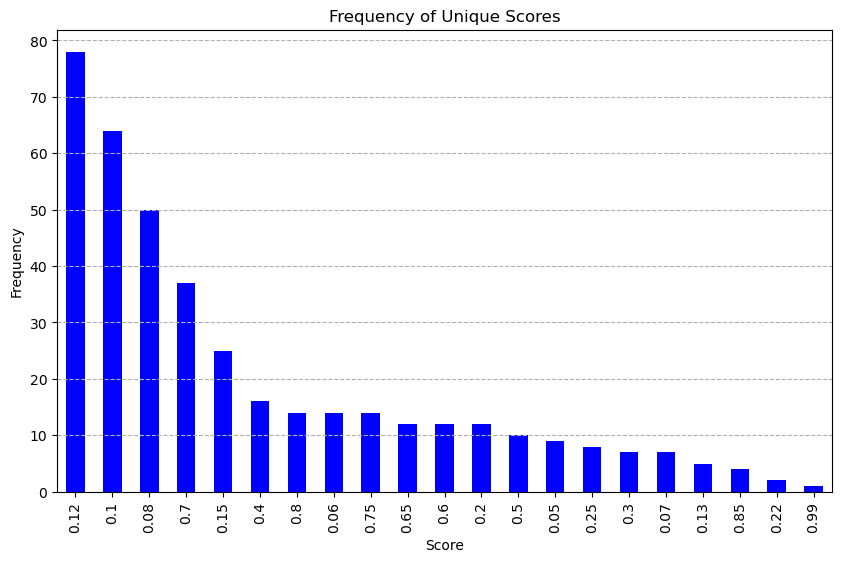

```python
# Show many scores are there
score_counts = movie['Score'].value_counts()


plt.figure(figsize=(10, 6))
score_counts.plot(kind='bar', color='blue')
plt.xlabel('Score')
plt.ylabel('Frequency')
plt.title('Frequency of Unique Scores')
plt.grid(axis='y', linestyle='--')
```

The highest and second highest score are 0.12 and 0.1. This shows that there is more positive reviews then negative.

I decide to do classification. Since, the data is limited, classification would give a higher accuracy for model compare to using regression. Thus, we will use classification to do our model.

I decide to Change score to 0 and 1. 0 is negative and 1 is positive. Since the lesser the score the higher the positivity. We change that lesser than 0.5 for scores is positive and higher than 0.5 is negative.

```python
movie['Score'] = movie['Score'].apply(lambda x: 1 if x <= 0.5 else 0)

movie
```

|  | Review | Score |
| --- | --- | --- |
| 0 | This movie is great!Thrilling action and shock... | 1 |
| 3 | Unfortunately, the actor didn't give the best ... | 0 |
| 4 | Complex and emotional storyline.So entertaining! | 1 |
| 5 | The filmmaker succeeded in providing an unforg... | 1 |
| 6 | Excessive and shocking action scenes.Sometimes... | 1 |
| ... | ... | ... |
| 522 | Dizzy | 0 |
| 523 | Effective | 1 |
| 524 | Exciting | 1 |
| 525 | Moderate and severe | 0 |
| 526 | Perfect | 1 |

401 rows × 2 columns

## f) Increase data by splitting punctuation

We want to split the data through punctuation to increase data to allow our model to train.

### Negative review

```python
# Split negative review with its punctuation for more data
neg = movie[movie['Score'] == 0]

neg['Review'] = neg['Review'].apply(lambda x: x.split('.'))
neg = neg.explode('Review')

neg['Review'] = neg['Review'].apply(lambda x: x.split('!'))
neg = neg.explode('Review')

neg
```

|  | Review | Score |
| --- | --- | --- |
| 3 | Unfortunately, the actor didn't give the best ... | 0 |
| 3 | Disappointed | 0 |
| 3 |  | 0 |
| 8 | Avengers: Endgame is frustrating and boring | 0 |
| 8 | Too many clichings | 0 |
| ... | ... | ... |
| 511 | Sad | 0 |
| 516 | Unsatisfactory | 0 |
| 520 | Chaos | 0 |
| 522 | Dizzy | 0 |
| 525 | Moderate and severe | 0 |

230 rows × 2 columns

### Positive review

```python
# Split positive review with its punctuation for more data
pos = movie[movie['Score'] == 1]

pos['Review'] = pos['Review'].apply(lambda x: x.split('.'))
pos = pos.explode('Review')

pos['Review'] = pos['Review'].apply(lambda x: x.split('!'))
pos = pos.explode('Review')


pos
```

|  | Review | Score |
| --- | --- | --- |
| 0 | This movie is great | 1 |
| 0 | Thrilling action and shocking plot | 1 |
| 0 |  | 1 |
| 4 | Complex and emotional storyline | 1 |
| 4 | So entertaining | 1 |
| ... | ... | ... |
| 519 | Fabulous | 1 |
| 521 | Adorable | 1 |
| 523 | Effective | 1 |
| 524 | Exciting | 1 |
| 526 | Perfect | 1 |

786 rows × 2 columns

### Combine both dataset into one

```python
mov_review = pd.concat([neg, pos], ignore_index=True)

# Remove any empty string columns
mov_review = mov_review[mov_review['Review'].str.strip() != '']

# Reset index
mov_review = mov_review.reset_index(drop=True)



mov_review
```

|  | Review | Score |
| --- | --- | --- |
| 0 | Unfortunately, the actor didn't give the best ... | 0 |
| 1 | Disappointed | 0 |
| 2 | Avengers: Endgame is frustrating and boring | 0 |
| 3 | Too many clichings | 0 |
| 4 | I think this movie is not as good as it says | 0 |
| ... | ... | ... |
| 727 | Fabulous | 1 |
| 728 | Adorable | 1 |
| 729 | Effective | 1 |
| 730 | Exciting | 1 |
| 731 | Perfect | 1 |

732 rows × 2 columns

### Remove duplicates again

```python
# Check whether there is duplicate
print("Before dropping duplicate:", mov_review.shape)
```

```
Before dropping duplicate: (732, 2)
```

```python
# Drop duplicate
mov_review = mov_review.copy()
mov_review.drop_duplicates(inplace=True)
```

```python
# Check whether there is duplicate
print("After dropping duplicate:", mov_review.shape)
```

```
After dropping duplicate: (653, 2)
```

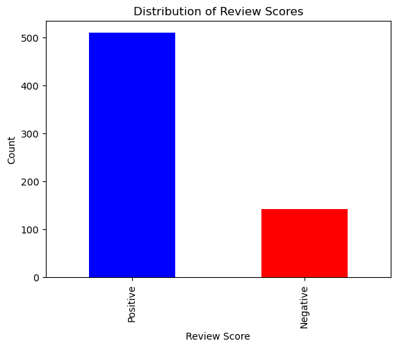

```python
# Show the score counts
score_counts = mov_review['Score'].value_counts()
# Plot bar graph
score_counts.plot(kind='bar', color=['blue', 'red'])
plt.xlabel('Review Score')
plt.ylabel('Count')
plt.title('Distribution of Review Scores')
plt.xticks([0, 1], ['Positive', 'Negative'])

plt.show()
```

We can see that there is more positive reviews then negative reviews

# 3) Tokenization

## a) Tokenize Review

```python
# Convert review data to a list.
rev = list(mov_review.Review.values)
print(f'There are {len(rev)} reviews in this dataset.')
print(rev[:10]) # Print first 10 reviews (it will be negative)
print(rev[-10:]) # Print end 10 reviews (it will be positive)
```

```
There are 653 reviews in this dataset.
["Unfortunately, the actor didn't give the best performance", 'Disappointed', 'Avengers: Endgame is frustrating and boring', 'Too many clichings', 'I think this movie is not as good as it says', 'Feeling dissatisfied', "I don't like the way the main actors deliver the dialogue", 'Less convincing', '…
['Expression of feelings', 'Emotion', 'Entertain', 'Rock', 'Epic hiking', 'Fabulous', 'Adorable', 'Effective', 'Exciting', 'Perfect']
```

```python
# Instantiate a Tokenizer object.
tokenizer = Tokenizer()

# Fit Tokenizer on rev. Map words into integer.
tokenizer.fit_on_texts(rev)

print(tokenizer.word_index)
```

```
{'the': 1, 'a': 2, 'of': 3, 'and': 4, 'is': 5, 'to': 6, 'this': 7, 'film': 8, 'action': 9, 'plot': 10, 'in': 11, 'avengers': 12, 'endgame': 13, 'with': 14, 'movie': 15, 'i': 16, 'effects': 17, 'visual': 18, 'are': 19, 'emotional': 20, 'narrative': 21, 'that': 22, 'cinematic': 23, 'character': 24, 'a…
```

## b) Show which is the most frequent words

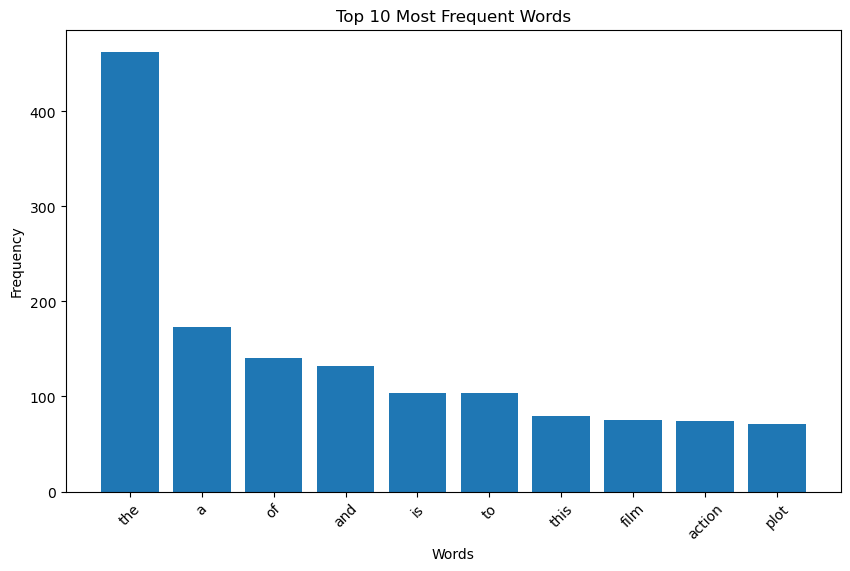

```python
# Get word counts
word_counts = tokenizer.word_counts
word_counts_movie = pd.DataFrame(list(word_counts.items()), columns=['word', 'count'])

# Sort the DataFrame by count in descending order
word_counts_movie = word_counts_movie.sort_values(by='count', ascending=False)



plt.figure(figsize=(10, 6))
# Plot top 10
plt.bar(word_counts_movie['word'][:10], word_counts_movie['count'][:10])
plt.xlabel('Words')
plt.ylabel('Frequency')
plt.title('Top 10 Most Frequent Words')
plt.xticks(rotation=45)
plt.show()
```

We can see that the, a and of are the three most frequent words

## b) Convert review into integer

```python
# Show how much total word is there for tokenizer in the review list
total_rev = len(tokenizer.word_index) + 1
print("The amount of word contain in the review list is:",total_rev)
```

```
The amount of word contain in the review list is: 822
```

```python
# Convert each reviews into integer

input_sequence = []

for datapoint in rev:
    token_list = tokenizer.texts_to_sequences([datapoint])[0]

    input_sequence.append(token_list)

# Show number of reviews
print(f'Total number of reviews: {len(input_sequence)}')
```

```
Total number of reviews: 653
```

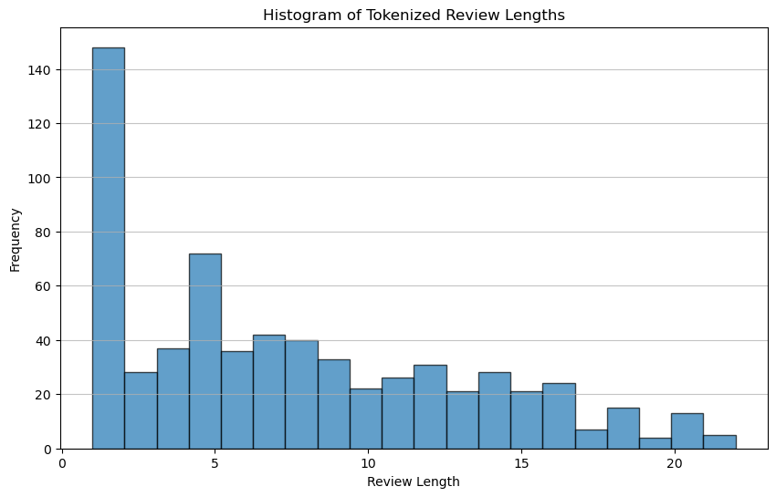

```python
# Find the length of each tokens
review_lengths = [len(tokens) for tokens in input_sequence]

# Create a histogram of the review lengths
plt.figure(figsize=(10, 6))
plt.hist(review_lengths, bins=20, edgecolor='k', alpha=0.7)
plt.title('Histogram of Tokenized Review Lengths')
plt.xlabel('Review Length')
plt.ylabel('Frequency')
plt.grid(axis='y', alpha=0.75)
plt.show()
```

```python
# This is to get the longest sequence of texts.
max_sequence_len = max([len(x) for x in input_sequence])

# Pad all datapoints to be of this length.
input_sequence = np.array(pad_sequences(input_sequence, maxlen=max_sequence_len, padding='pre'))

# Show input_sequence
print(input_sequence)
```

```
[[  0   0   0 ...   1 497  83]
 [  0   0   0 ...   0   0 265]
 [  0   0   0 ... 363   4 498]
 ...
 [  0   0   0 ...   0   0 373]
 [  0   0   0 ...   0   0 400]
 [  0   0   0 ...   0   0 821]]
```

# 4) Convert the data into X and y

```python
# Convert into X and y
X = np.array(input_sequence)
y = np.array(mov_review['Score'])
print(X)
print(y)
```

```
[[  0   0   0 ...   1 497  83]
 [  0   0   0 ...   0   0 265]
 [  0   0   0 ... 363   4 498]
 ...
 [  0   0   0 ...   0   0 373]
 [  0   0   0 ...   0   0 400]
 [  0   0   0 ...   0   0 821]]
[0 0 0 0 0 0 0 0 0 0 0 0 0 0 0 0 0 0 0 0 0 0 0 0 0 0 0 0 0 0 0 0 0 0 0 0 0
 0 0 0 0 0 0 0 0 0 0 0 0 0 0 0 0 0 0 0 0 0 0 0 0 0 0 0 0 0 0 0 0 0 0 0 0 0
 0 0 0 0 0 0 0 0 0 0 0 0 0 0 0 0 0 0 0 0 0 0 0 0 0 0 0 0 0 0 0 0 0 0 0 0 0
 0 0 0 0 0 0 0 0 0 0 0 0 0 0 0 0 0 0 0 0 0 0 0 0 0 0 0 0 0 0 0 0 1 1 1 1 1
 1 1 1 1 1 1 1 1 1 1 1 1 1 1 1 1 1 1 1 1 1 1 1 1 1 1 1 1 1 1 1 1 1 1 1 1 1
 1 1 1 1 1 1 1 1 1 1 1 1 1 1 1 1 1 1 1 1 1 1 1 1 1 1 1 1 1 1 1 1 1 1 1 1 1
 1 1 1 1 1 1 1 1 1 1 1 1 1 1 1 1 1 1 1 1 1 1 1 1 1 1 1 1 1 1 1 1 1 1 1 1 1
 1 1 1 1 1 1 1 1 1 1 1 1 1 1 1 1 1 1 1 1 1 1 1 1 1 1 1 1 1 1 1 1 1 1 1 1 1
 1 1 1 1 1 1 1 1 1 1 1 1 1 1 1 1 1 1 1 1 1 1 1 1 1 1 1 1 1 1 1 1 1 1 1 1 1
 1 1 1 1 1 1 1 1 1 1 1 1 1 1 1 1 1 1 1 1 1 1 1 1 1 1 1 1 1 1 1 1 1 1 1 1 1
 1 1 1 1 1 1 1 1 1 1 1 1 1 1 1 1 1 1 1 1 1 1 1 1 1 1 1 1 1 1 1 1 1 1 1 1 1
 1 1 1 1 1 1 1 1 1 1 1 1 1 1 1 1 1 1 1 1 1 1 1 1 1 1 1 1 1 1 1 1 1 1 1 1 1
 1 1 1 1 1 1 1 1 1 1 1 1 1 1 1 1 1 1 1 1 1 1 1 1 1 1 1 1 1 1 1 1 1 1 1 1 1
 1 1 1 1 1 1 1 1 1 1 1 1 1 1 1 1 1 1 1 1 1 1 1 1 1 1 1 1 1 1 1 1 1 1 1 1 1
 1 1 1 1 1 1 1 1 1 1 1 1 1 1 1 1 1 1 1 1 1 1 1 1 1 1 1 1 1 1 1 1 1 1 1 1 1
 1 1 1 1 1 1 1 1 1 1 1 1 1 1 1 1 1 1 1 1 1 1 1 1 1 1 1 1 1 1 1 1 1 1 1 1 1
 1 1 1 1 1 1 1 1 1 1 1 1 1 1 1 1 1 1 1 1 1 1 1 1 1 1 1 1 1 1 1 1 1 1 1 1 1
 1 1 1 1 1 1 1 1 1 1 1 1 1 1 1 1 1 1 1 1 1 1 1 1]
```

```python
# Get the vocab_size for model later
vocab_size = np.max(X) + 1
```

## a) One hot encoder

```python
from sklearn.preprocessing import OneHotEncoder


y = y.reshape(-1, 1)

# One-hot encode the data
y = np.eye(2)[y.flatten()]

y
```

```
array([[1., 0.],
       [1., 0.],
       [1., 0.],
       ...,
       [0., 1.],
       [0., 1.],
       [0., 1.]])
```

## b) Train test split

```python
from sklearn.model_selection import train_test_split

# Split data into train and test sets
X_train, X_test, y_train, y_test = train_test_split(X, y, test_size=0.2, random_state=42)

# Optionally, further split the training data into train and validation sets
X_train, X_val, y_train, y_val = train_test_split(X_train, y_train, test_size=0.1, random_state=42)
```

```python
print("Number of samples in training set:", len(X_train))
print("Number of samples in validation set:", len(X_val))
print("Number of samples in testing set:", len(X_test))
```

```
Number of samples in training set: 469
Number of samples in validation set: 53
Number of samples in testing set: 131
```

```python
print("Number of labels in training set:", len(y_train))
print("Number of labels in validation set:", len(y_val))
print("Number of labels in testing set:", len(y_test))
```

```
Number of labels in training set: 469
Number of labels in validation set: 53
Number of labels in testing set: 131
```

# 3) Modelling

```python
from sklearn.preprocessing import LabelEncoder
```

```python
from tensorflow.keras.layers import Embedding, Bidirectional, LSTM, Dropout, Dense
from keras.regularizers import l2
```

## a) Base Model

Let start by creating a simple model to see how well it fits with the sample.

```python
# Define the model
base_model = Sequential()
base_model.add(Embedding(input_dim=vocab_size, output_dim=32))
base_model.add((LSTM(units=64, return_sequences=True)))
base_model.add((LSTM(units=32)))
base_model.add(Dense(units=2, activation='softmax'))

# Compile the model
base_model.compile(optimizer='adam', loss='categorical_crossentropy', metrics=['accuracy'])



# Print model summary
base_model.summary()
```

```
Model: "sequential"
_________________________________________________________________
 Layer (type)                Output Shape              Param #
=================================================================
 embedding (Embedding)       (None, None, 32)          26304

 lstm (LSTM)                 (None, None, 64)          24832

 lstm_1 (LSTM)               (None, 32)                12416

 dense (Dense)               (None, 2)                 66

=================================================================
Total params: 63,618
Trainable params: 63,618
Non-trainable params: 0
_________________________________________________________________
```

```python
base_history = base_model.fit(X_train, y_train, validation_data=(X_val, y_val), epochs=200, batch_size=13, verbose=2)
```

```
37/37 - 7s - loss: 0.5449 - accuracy: 0.7910 - val_loss: 0.4559 - val_accuracy: 0.8302 - 7s/epoch - 192ms/step
37/37 - 0s - loss: 0.4996 - accuracy: 0.7932 - val_loss: 0.4494 - val_accuracy: 0.8302 - 437ms/epoch - 12ms/step
37/37 - 0s - loss: 0.4370 - accuracy: 0.7932 - val_loss: 0.4889 - val_accuracy: 0.8302 - 411ms/epoch - 11ms/step
37/37 - 0s - loss: 0.4079 - accuracy: 0.8166 - val_loss: 0.4455 - val_accuracy: 0.8302 - 376ms/epoch - 10ms/step
37/37 - 0s - loss: 0.2891 - accuracy: 0.8635 - val_loss: 0.4722 - val_accuracy: 0.8491 - 350ms/epoch - 9ms/step
37/37 - 0s - loss: 0.2127 - accuracy: 0.9275 - val_loss: 0.4300 - val_accuracy: 0.8868 - 333ms/epoch - 9ms/step
37/37 - 0s - loss: 0.1329 - accuracy: 0.9616 - val_loss: 0.4688 - val_accuracy: 0.8868 - 390ms/epoch - 11ms/step
37/37 - 0s - loss: 0.0888 - accuracy: 0.9765 - val_loss: 0.4852 - val_accuracy: 0.9057 - 376ms/epoch - 10ms/step
37/37 - 0s - loss: 0.0778 - accuracy: 0.9765 - val_loss: 0.4838 - val_accuracy: 0.9245 - 390ms/epoch - 11ms/step
37/37 - 0s - loss: 0.0504 - accuracy: 0.9872 - val_loss: 0.5368 - val_accuracy: 0.8679 - 352ms/epoch - 10ms/step
37/37 - 0s - loss: 0.0447 - accuracy: 0.9893 - val_loss: 0.5235 - val_accuracy: 0.9245 - 442ms/epoch - 12ms/step
37/37 - 0s - loss: 0.0381 - accuracy: 0.9915 - val_loss: 0.5099 - val_accuracy: 0.9057 - 395ms/epoch - 11ms/step
37/37 - 0s - loss: 0.0325 - accuracy: 0.9936 - val_loss: 0.5296 - val_accuracy: 0.9057 - 421ms/epoch - 11ms/step
37/37 - 0s - loss: 0.0278 - accuracy: 0.9936 - val_loss: 0.5476 - val_accuracy: 0.9057 - 416ms/epoch - 11ms/step
37/37 - 0s - loss: 0.0223 - accuracy: 0.9936 - val_loss: 0.5604 - val_accuracy: 0.9057 - 472ms/epoch - 13ms/step
37/37 - 0s - loss: 0.0182 - accuracy: 0.9936 - val_loss: 0.5727 - val_accuracy: 0.9057 - 406ms/epoch - 11ms/step
37/37 - 0s - loss: 0.0170 - accuracy: 0.9936 - val_loss: 0.6338 - val_accuracy: 0.8491 - 433ms/epoch - 12ms/step
37/37 - 0s - loss: 0.0109 - accuracy: 0.9957 - val_loss: 0.6456 - val_accuracy: 0.8679 - 437ms/epoch - 12ms/step
37/37 - 0s - loss: 0.0103 - accuracy: 0.9957 - val_loss: 0.6581 - val_accuracy: 0.8679 - 473ms/epoch - 13ms/step
37/37 - 0s - loss: 0.0128 - accuracy: 0.9957 - val_loss: 0.6624 - val_accuracy: 0.8679 - 405ms/epoch - 11ms/step
37/37 - 1s - loss: 0.0070 - accuracy: 0.9979 - val_loss: 0.6867 - val_accuracy: 0.8679 - 717ms/epoch - 19ms/step
37/37 - 1s - loss: 0.0040 - accuracy: 1.0000 - val_loss: 0.7360 - val_accuracy: 0.8868 - 667ms/epoch - 18ms/step
37/37 - 0s - loss: 0.0016 - accuracy: 1.0000 - val_loss: 0.7830 - val_accuracy: 0.8868 - 391ms/epoch - 11ms/step
37/37 - 0s - loss: 0.0019 - accuracy: 1.0000 - val_loss: 0.7876 - val_accuracy: 0.8679 - 407ms/epoch - 11ms/step
37/37 - 1s - loss: 0.0012 - accuracy: 1.0000 - val_loss: 0.8195 - val_accuracy: 0.8679 - 552ms/epoch - 15ms/step
37/37 - 0s - loss: 6.8261e-04 - accuracy: 1.0000 - val_loss: 0.8351 - val_accuracy: 0.8679 - 410ms/epoch - 11ms/step
37/37 - 0s - loss: 4.3737e-04 - accuracy: 1.0000 - val_loss: 0.8565 - val_accuracy: 0.8679 - 351ms/epoch - 9ms/step
37/37 - 0s - loss: 3.5265e-04 - accuracy: 1.0000 - val_loss: 0.8666 - val_accuracy: 0.8868 - 425ms/epoch - 11ms/step
37/37 - 0s - loss: 3.5529e-04 - accuracy: 1.0000 - val_loss: 0.8774 - val_accuracy: 0.8868 - 488ms/epoch - 13ms/step
37/37 - 1s - loss: 2.4393e-04 - accuracy: 1.0000 - val_loss: 0.8848 - val_accuracy: 0.8868 - 591ms/epoch - 16ms/step
37/37 - 0s - loss: 2.2301e-04 - accuracy: 1.0000 - val_loss: 0.8927 - val_accuracy: 0.8868 - 484ms/epoch - 13ms/step
37/37 - 0s - loss: 2.3712e-04 - accuracy: 1.0000 - val_loss: 0.9057 - val_accuracy: 0.8679 - 387ms/epoch - 10ms/step
37/37 - 0s - loss: 2.1270e-04 - accuracy: 1.0000 - val_loss: 0.9091 - val_accuracy: 0.8868 - 379ms/epoch - 10ms/step
37/37 - 0s - loss: 1.9030e-04 - accuracy: 1.0000 - val_loss: 0.9154 - val_accuracy: 0.8868 - 381ms/epoch - 10ms/step
37/37 - 0s - loss: 1.8319e-04 - accuracy: 1.0000 - val_loss: 0.9202 - val_accuracy: 0.8868 - 431ms/epoch - 12ms/step
37/37 - 1s - loss: 1.6513e-04 - accuracy: 1.0000 - val_loss: 0.9255 - val_accuracy: 0.8679 - 715ms/epoch - 19ms/step
37/37 - 1s - loss: 1.6753e-04 - accuracy: 1.0000 - val_loss: 0.9316 - val_accuracy: 0.8868 - 532ms/epoch - 14ms/step
37/37 - 0s - loss: 1.3232e-04 - accuracy: 1.0000 - val_loss: 0.9348 - val_accuracy: 0.8868 - 365ms/epoch - 10ms/step
37/37 - 1s - loss: 1.2947e-04 - accuracy: 1.0000 - val_loss: 0.9397 - val_accuracy: 0.8868 - 747ms/epoch - 20ms/step
37/37 - 0s - loss: 1.2331e-04 - accuracy: 1.0000 - val_loss: 0.9490 - val_accuracy: 0.8868 - 435ms/epoch - 12ms/step
```

[output cut: 145 more lines]

```
37/37 - 0s - loss: 2.1844e-06 - accuracy: 1.0000 - val_loss: 1.4011 - val_accuracy: 0.8491 - 326ms/epoch - 9ms/step
37/37 - 0s - loss: 2.2354e-06 - accuracy: 1.0000 - val_loss: 1.4032 - val_accuracy: 0.8491 - 333ms/epoch - 9ms/step
37/37 - 0s - loss: 2.1523e-06 - accuracy: 1.0000 - val_loss: 1.4043 - val_accuracy: 0.8491 - 365ms/epoch - 10ms/step
37/37 - 0s - loss: 2.1478e-06 - accuracy: 1.0000 - val_loss: 1.4059 - val_accuracy: 0.8491 - 358ms/epoch - 10ms/step
37/37 - 0s - loss: 2.0784e-06 - accuracy: 1.0000 - val_loss: 1.4068 - val_accuracy: 0.8491 - 434ms/epoch - 12ms/step
37/37 - 0s - loss: 2.0428e-06 - accuracy: 1.0000 - val_loss: 1.4078 - val_accuracy: 0.8491 - 358ms/epoch - 10ms/step
37/37 - 0s - loss: 2.0179e-06 - accuracy: 1.0000 - val_loss: 1.4090 - val_accuracy: 0.8491 - 353ms/epoch - 10ms/step
37/37 - 0s - loss: 1.9701e-06 - accuracy: 1.0000 - val_loss: 1.4108 - val_accuracy: 0.8491 - 363ms/epoch - 10ms/step
37/37 - 0s - loss: 1.9294e-06 - accuracy: 1.0000 - val_loss: 1.4110 - val_accuracy: 0.8491 - 367ms/epoch - 10ms/step
37/37 - 0s - loss: 2.0471e-06 - accuracy: 1.0000 - val_loss: 1.4134 - val_accuracy: 0.8491 - 393ms/epoch - 11ms/step
37/37 - 0s - loss: 1.9015e-06 - accuracy: 1.0000 - val_loss: 1.4139 - val_accuracy: 0.8491 - 406ms/epoch - 11ms/step
37/37 - 0s - loss: 1.9045e-06 - accuracy: 1.0000 - val_loss: 1.4145 - val_accuracy: 0.8491 - 411ms/epoch - 11ms/step
37/37 - 0s - loss: 1.8941e-06 - accuracy: 1.0000 - val_loss: 1.4166 - val_accuracy: 0.8491 - 363ms/epoch - 10ms/step
37/37 - 0s - loss: 1.7901e-06 - accuracy: 1.0000 - val_loss: 1.4176 - val_accuracy: 0.8491 - 365ms/epoch - 10ms/step
37/37 - 0s - loss: 1.7843e-06 - accuracy: 1.0000 - val_loss: 1.4185 - val_accuracy: 0.8491 - 360ms/epoch - 10ms/step
```

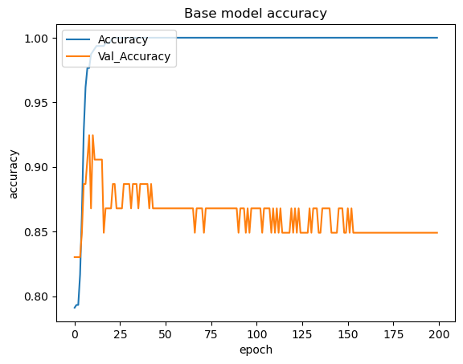

```python
# History of base model for RNN
plt.plot(base_history.history['accuracy'])
plt.plot(base_history.history['val_accuracy'])
plt.title('Base model accuracy')
plt.ylabel('accuracy')
plt.xlabel('epoch')
plt.legend(['Accuracy', 'Val_Accuracy'], loc='upper left')
plt.show()
```

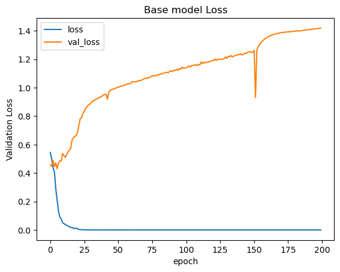

```python
# History of base model for RNN
plt.plot(base_history.history['loss'])
plt.plot(base_history.history['val_loss'])
plt.title('Base model Loss')
plt.ylabel('Validation Loss')
plt.xlabel('epoch')
plt.legend(['loss', 'val_loss'], loc='upper left')
plt.show()
```

# b) Hyperparameter tuning model (Model Improvement) (LSTM)

```python
# Define the model
model_tune = Sequential()
model_tune.add(Embedding(input_dim=vocab_size, output_dim=32))
# Bidirectional helps input sequence both forwards and backwards, which helps it capture context from both directions.
model_tune.add(Bidirectional(LSTM(units=64, return_sequences=True, kernel_regularizer=l2(0.01), recurrent_regularizer=l2(0.01))))
# Prevent overfitting
model_tune.add(Dropout(0.1))
# Improve the training speed and stability
model_tune.add(BatchNormalization())

# Add more layers
model_tune.add(Bidirectional(LSTM(units=32, kernel_regularizer=l2(0.01), recurrent_regularizer=l2(0.01))))
model_tune.add(Dropout(0.3))
model_tune.add(BatchNormalization())
model_tune.add(Dense(units=2, activation='softmax'))

# Compile the model
optimizer = Adam(learning_rate=0.0001)
model_tune.compile(optimizer=optimizer, loss='categorical_crossentropy', metrics=['accuracy'])



# Print model summary
model_tune.summary()
```

```
Model: "sequential_12"
_________________________________________________________________
 Layer (type)                Output Shape              Param #
=================================================================
 embedding_12 (Embedding)    (None, None, 32)          26304

 bidirectional_22 (Bidirecti  (None, None, 128)        49664
 onal)

 dropout_22 (Dropout)        (None, None, 128)         0

 batch_normalization_22 (Bat  (None, None, 128)        512
 chNormalization)

 bidirectional_23 (Bidirecti  (None, 64)               41216
 onal)

 dropout_23 (Dropout)        (None, 64)                0

 batch_normalization_23 (Bat  (None, 64)               256
 chNormalization)

 dense_12 (Dense)            (None, 2)                 130

=================================================================
Total params: 118,082
Trainable params: 117,698
Non-trainable params: 384
_________________________________________________________________
```

```python
history_tune = model_tune.fit(X_train, y_train, validation_data=(X_val, y_val), epochs=200, batch_size=13, verbose=2)
```

```
37/37 - 8s - loss: 6.3362 - accuracy: 0.5245 - val_loss: 6.0391 - val_accuracy: 0.1698 - 8s/epoch - 203ms/step
37/37 - 1s - loss: 6.0132 - accuracy: 0.5267 - val_loss: 5.7695 - val_accuracy: 0.1698 - 665ms/epoch - 18ms/step
37/37 - 1s - loss: 5.6635 - accuracy: 0.6013 - val_loss: 5.5221 - val_accuracy: 0.1698 - 650ms/epoch - 18ms/step
37/37 - 1s - loss: 5.3751 - accuracy: 0.6439 - val_loss: 5.2828 - val_accuracy: 0.1698 - 650ms/epoch - 18ms/step
37/37 - 1s - loss: 5.1270 - accuracy: 0.6333 - val_loss: 5.0622 - val_accuracy: 0.1698 - 670ms/epoch - 18ms/step
37/37 - 1s - loss: 4.8995 - accuracy: 0.6311 - val_loss: 4.8496 - val_accuracy: 0.1887 - 663ms/epoch - 18ms/step
37/37 - 1s - loss: 4.6397 - accuracy: 0.6908 - val_loss: 4.6335 - val_accuracy: 0.2264 - 662ms/epoch - 18ms/step
37/37 - 1s - loss: 4.4333 - accuracy: 0.6759 - val_loss: 4.4364 - val_accuracy: 0.4340 - 672ms/epoch - 18ms/step
37/37 - 1s - loss: 4.2143 - accuracy: 0.7292 - val_loss: 4.2476 - val_accuracy: 0.5660 - 648ms/epoch - 18ms/step
37/37 - 1s - loss: 3.9924 - accuracy: 0.7377 - val_loss: 4.0755 - val_accuracy: 0.5472 - 659ms/epoch - 18ms/step
37/37 - 1s - loss: 3.7974 - accuracy: 0.7697 - val_loss: 3.9458 - val_accuracy: 0.4340 - 710ms/epoch - 19ms/step
37/37 - 1s - loss: 3.6511 - accuracy: 0.7676 - val_loss: 3.7295 - val_accuracy: 0.7170 - 685ms/epoch - 19ms/step
37/37 - 1s - loss: 3.4764 - accuracy: 0.7889 - val_loss: 3.5580 - val_accuracy: 0.8113 - 683ms/epoch - 18ms/step
37/37 - 1s - loss: 3.2560 - accuracy: 0.8550 - val_loss: 3.4179 - val_accuracy: 0.7547 - 702ms/epoch - 19ms/step
37/37 - 1s - loss: 3.1448 - accuracy: 0.8486 - val_loss: 3.2074 - val_accuracy: 0.8113 - 689ms/epoch - 19ms/step
37/37 - 1s - loss: 2.9592 - accuracy: 0.8806 - val_loss: 3.1246 - val_accuracy: 0.8491 - 674ms/epoch - 18ms/step
37/37 - 1s - loss: 2.8534 - accuracy: 0.8614 - val_loss: 3.0344 - val_accuracy: 0.8113 - 698ms/epoch - 19ms/step
37/37 - 1s - loss: 2.7348 - accuracy: 0.8763 - val_loss: 2.9467 - val_accuracy: 0.8113 - 662ms/epoch - 18ms/step
37/37 - 1s - loss: 2.6028 - accuracy: 0.8849 - val_loss: 2.8401 - val_accuracy: 0.8113 - 664ms/epoch - 18ms/step
37/37 - 1s - loss: 2.4713 - accuracy: 0.9041 - val_loss: 2.7136 - val_accuracy: 0.8491 - 675ms/epoch - 18ms/step
37/37 - 1s - loss: 2.3644 - accuracy: 0.9190 - val_loss: 2.5711 - val_accuracy: 0.8113 - 702ms/epoch - 19ms/step
37/37 - 1s - loss: 2.2470 - accuracy: 0.9275 - val_loss: 2.5279 - val_accuracy: 0.8302 - 861ms/epoch - 23ms/step
37/37 - 1s - loss: 2.1412 - accuracy: 0.9403 - val_loss: 2.4544 - val_accuracy: 0.8302 - 718ms/epoch - 19ms/step
37/37 - 1s - loss: 2.0536 - accuracy: 0.9488 - val_loss: 2.4155 - val_accuracy: 0.8302 - 693ms/epoch - 19ms/step
37/37 - 1s - loss: 1.9952 - accuracy: 0.9296 - val_loss: 2.3905 - val_accuracy: 0.8302 - 675ms/epoch - 18ms/step
37/37 - 1s - loss: 1.9079 - accuracy: 0.9446 - val_loss: 2.4360 - val_accuracy: 0.7736 - 734ms/epoch - 20ms/step
37/37 - 1s - loss: 1.8328 - accuracy: 0.9296 - val_loss: 2.2774 - val_accuracy: 0.8302 - 815ms/epoch - 22ms/step
37/37 - 1s - loss: 1.7644 - accuracy: 0.9488 - val_loss: 2.2778 - val_accuracy: 0.8302 - 830ms/epoch - 22ms/step
37/37 - 1s - loss: 1.6639 - accuracy: 0.9701 - val_loss: 2.2976 - val_accuracy: 0.8491 - 822ms/epoch - 22ms/step
37/37 - 1s - loss: 1.6204 - accuracy: 0.9616 - val_loss: 2.3001 - val_accuracy: 0.7925 - 673ms/epoch - 18ms/step
37/37 - 1s - loss: 1.5577 - accuracy: 0.9723 - val_loss: 2.0563 - val_accuracy: 0.8113 - 899ms/epoch - 24ms/step
37/37 - 1s - loss: 1.5203 - accuracy: 0.9595 - val_loss: 1.9446 - val_accuracy: 0.8113 - 855ms/epoch - 23ms/step
37/37 - 1s - loss: 1.4439 - accuracy: 0.9638 - val_loss: 1.9143 - val_accuracy: 0.8113 - 803ms/epoch - 22ms/step
37/37 - 1s - loss: 1.3890 - accuracy: 0.9680 - val_loss: 1.9280 - val_accuracy: 0.8302 - 998ms/epoch - 27ms/step
37/37 - 1s - loss: 1.3418 - accuracy: 0.9765 - val_loss: 2.0486 - val_accuracy: 0.8113 - 842ms/epoch - 23ms/step
37/37 - 1s - loss: 1.2986 - accuracy: 0.9765 - val_loss: 1.9282 - val_accuracy: 0.8302 - 745ms/epoch - 20ms/step
37/37 - 1s - loss: 1.2631 - accuracy: 0.9744 - val_loss: 2.0303 - val_accuracy: 0.8302 - 795ms/epoch - 21ms/step
37/37 - 1s - loss: 1.2273 - accuracy: 0.9765 - val_loss: 2.0231 - val_accuracy: 0.8113 - 749ms/epoch - 20ms/step
37/37 - 1s - loss: 1.1808 - accuracy: 0.9723 - val_loss: 1.8715 - val_accuracy: 0.8302 - 718ms/epoch - 19ms/step
37/37 - 1s - loss: 1.1598 - accuracy: 0.9723 - val_loss: 1.8436 - val_accuracy: 0.8302 - 792ms/epoch - 21ms/step
```

[output cut: 145 more lines]

```
37/37 - 1s - loss: 0.0725 - accuracy: 0.9979 - val_loss: 1.0933 - val_accuracy: 0.8113 - 691ms/epoch - 19ms/step
37/37 - 1s - loss: 0.0661 - accuracy: 1.0000 - val_loss: 1.0761 - val_accuracy: 0.8113 - 710ms/epoch - 19ms/step
37/37 - 1s - loss: 0.0675 - accuracy: 0.9979 - val_loss: 1.2097 - val_accuracy: 0.8113 - 885ms/epoch - 24ms/step
37/37 - 1s - loss: 0.0664 - accuracy: 1.0000 - val_loss: 1.1181 - val_accuracy: 0.7925 - 739ms/epoch - 20ms/step
37/37 - 1s - loss: 0.0623 - accuracy: 1.0000 - val_loss: 1.0839 - val_accuracy: 0.8113 - 774ms/epoch - 21ms/step
37/37 - 1s - loss: 0.0624 - accuracy: 0.9957 - val_loss: 1.2579 - val_accuracy: 0.8113 - 702ms/epoch - 19ms/step
37/37 - 1s - loss: 0.0610 - accuracy: 0.9979 - val_loss: 0.9336 - val_accuracy: 0.7925 - 696ms/epoch - 19ms/step
37/37 - 1s - loss: 0.0691 - accuracy: 0.9957 - val_loss: 1.0236 - val_accuracy: 0.8113 - 642ms/epoch - 17ms/step
37/37 - 1s - loss: 0.0609 - accuracy: 1.0000 - val_loss: 1.0475 - val_accuracy: 0.8113 - 726ms/epoch - 20ms/step
37/37 - 1s - loss: 0.0675 - accuracy: 0.9979 - val_loss: 1.1418 - val_accuracy: 0.8113 - 739ms/epoch - 20ms/step
37/37 - 1s - loss: 0.0584 - accuracy: 1.0000 - val_loss: 1.0849 - val_accuracy: 0.8113 - 705ms/epoch - 19ms/step
37/37 - 1s - loss: 0.0554 - accuracy: 1.0000 - val_loss: 1.0976 - val_accuracy: 0.8113 - 728ms/epoch - 20ms/step
37/37 - 1s - loss: 0.0594 - accuracy: 0.9979 - val_loss: 1.0597 - val_accuracy: 0.7925 - 685ms/epoch - 19ms/step
37/37 - 1s - loss: 0.0517 - accuracy: 1.0000 - val_loss: 1.1654 - val_accuracy: 0.8302 - 672ms/epoch - 18ms/step
37/37 - 1s - loss: 0.0518 - accuracy: 1.0000 - val_loss: 1.1111 - val_accuracy: 0.8302 - 697ms/epoch - 19ms/step
```

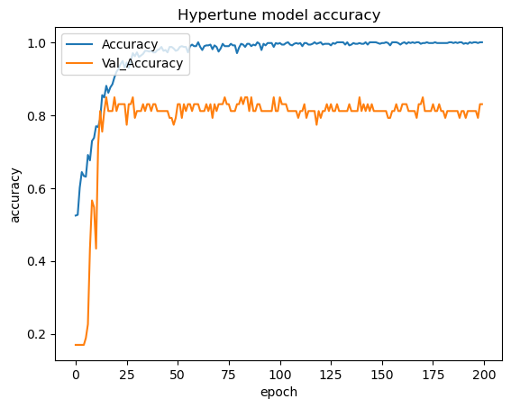

```python
# History of hypertune model for RNN
plt.plot(history_tune.history['accuracy'])
plt.plot(history_tune.history['val_accuracy'])
plt.title('Hypertune model accuracy')
plt.ylabel('accuracy')
plt.xlabel('epoch')
plt.legend(['Accuracy', 'Val_Accuracy'], loc='upper left')
plt.show()
```

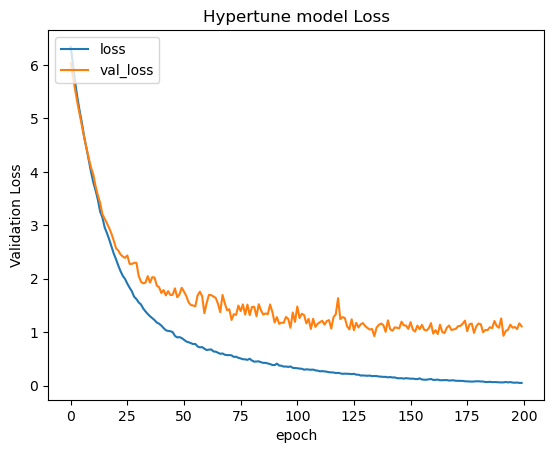

```python
# History of hypertune model for RNN
plt.plot(history_tune.history['loss'])
plt.plot(history_tune.history['val_loss'])
plt.title('Hypertune model Loss')
plt.ylabel('Validation Loss')
plt.xlabel('epoch')
plt.legend(['loss', 'val_loss'], loc='upper left')
plt.show()
```

```python
scores_LSTM = model_tune_loaded.evaluate(X_test, y_test)

print(f"\n Accuracy: {round(scores_LSTM[1]*100, 2)}%")
```

```
 Accuracy: 85.5%
```

# c) Use another Model (GRU)

We will use GRU (Gated Recurrent Unit) model to see whether it help for our sequence model

```python
# Import GRU
from tensorflow.keras.layers import GRU
```

```python
# Define the model
model_tune_gru = Sequential()
model_tune_gru.add(Embedding(input_dim=vocab_size, output_dim=32))
# Bidirectional helps input sequence both forwards and backwards, which helps it capture context from both directions.
model_tune_gru.add(Bidirectional(GRU(units=64, return_sequences=True, kernel_regularizer=l2(0.01), recurrent_regularizer=l2(0.01))))
# Prevent overfitting
model_tune_gru.add(Dropout(0.1))
# Improve the training speed and stability
model_tune_gru.add(BatchNormalization())

# Add more layers
model_tune_gru.add(Bidirectional(GRU(units=32, kernel_regularizer=l2(0.01), recurrent_regularizer=l2(0.01))))
model_tune_gru.add(Dropout(0.3))
model_tune_gru.add(BatchNormalization())
model_tune_gru.add(Dense(units=2, activation='softmax'))

# Compile the model
optimizer = Adam(learning_rate=0.0001)
model_tune_gru.compile(optimizer=optimizer, loss='categorical_crossentropy', metrics=['accuracy'])



# Print model summary
model_tune_gru.summary()
```

```
Model: "sequential_1"
_________________________________________________________________
 Layer (type)                Output Shape              Param #
=================================================================
 embedding_1 (Embedding)     (None, None, 32)          26304

 bidirectional (Bidirectiona  (None, None, 128)        37632
 l)

 dropout (Dropout)           (None, None, 128)         0

 batch_normalization (BatchN  (None, None, 128)        512
 ormalization)

 bidirectional_1 (Bidirectio  (None, 64)               31104
 nal)

 dropout_1 (Dropout)         (None, 64)                0

 batch_normalization_1 (Batc  (None, 64)               256
 hNormalization)

 dense (Dense)               (None, 2)                 130

=================================================================
Total params: 95,938
Trainable params: 95,554
Non-trainable params: 384
_________________________________________________________________
```

```python
history_tune_gru = model_tune_gru.fit(X_train, y_train, validation_data=(X_val, y_val), epochs=200, batch_size=13, verbose=2)
```

```
37/37 - 9s - loss: 6.0749 - accuracy: 0.5586 - val_loss: 5.7216 - val_accuracy: 0.1698 - 9s/epoch - 247ms/step
37/37 - 1s - loss: 5.8338 - accuracy: 0.5416 - val_loss: 5.5240 - val_accuracy: 0.1698 - 988ms/epoch - 27ms/step
37/37 - 1s - loss: 5.5773 - accuracy: 0.5480 - val_loss: 5.3333 - val_accuracy: 0.1698 - 728ms/epoch - 20ms/step
37/37 - 1s - loss: 5.2128 - accuracy: 0.5800 - val_loss: 5.1362 - val_accuracy: 0.1698 - 684ms/epoch - 18ms/step
37/37 - 1s - loss: 4.9970 - accuracy: 0.6418 - val_loss: 4.9508 - val_accuracy: 0.1698 - 742ms/epoch - 20ms/step
37/37 - 1s - loss: 4.8565 - accuracy: 0.5842 - val_loss: 4.7476 - val_accuracy: 0.2264 - 626ms/epoch - 17ms/step
37/37 - 1s - loss: 4.6092 - accuracy: 0.6333 - val_loss: 4.5482 - val_accuracy: 0.4528 - 636ms/epoch - 17ms/step
37/37 - 1s - loss: 4.4241 - accuracy: 0.6695 - val_loss: 4.3677 - val_accuracy: 0.6415 - 687ms/epoch - 19ms/step
37/37 - 1s - loss: 4.2611 - accuracy: 0.6994 - val_loss: 4.2264 - val_accuracy: 0.5283 - 638ms/epoch - 17ms/step
37/37 - 1s - loss: 4.0982 - accuracy: 0.7143 - val_loss: 4.0541 - val_accuracy: 0.7358 - 620ms/epoch - 17ms/step
37/37 - 1s - loss: 3.8952 - accuracy: 0.7271 - val_loss: 3.9159 - val_accuracy: 0.7358 - 704ms/epoch - 19ms/step
37/37 - 1s - loss: 3.7298 - accuracy: 0.7548 - val_loss: 3.7861 - val_accuracy: 0.6415 - 626ms/epoch - 17ms/step
37/37 - 1s - loss: 3.5808 - accuracy: 0.7953 - val_loss: 3.6846 - val_accuracy: 0.5849 - 627ms/epoch - 17ms/step
37/37 - 1s - loss: 3.4004 - accuracy: 0.7996 - val_loss: 3.5962 - val_accuracy: 0.5472 - 635ms/epoch - 17ms/step
37/37 - 1s - loss: 3.2812 - accuracy: 0.8145 - val_loss: 3.4677 - val_accuracy: 0.6226 - 655ms/epoch - 18ms/step
37/37 - 1s - loss: 3.1758 - accuracy: 0.8188 - val_loss: 3.3446 - val_accuracy: 0.6981 - 636ms/epoch - 17ms/step
37/37 - 1s - loss: 3.0052 - accuracy: 0.8529 - val_loss: 3.2049 - val_accuracy: 0.6981 - 634ms/epoch - 17ms/step
37/37 - 1s - loss: 2.9084 - accuracy: 0.8486 - val_loss: 3.1297 - val_accuracy: 0.7170 - 677ms/epoch - 18ms/step
37/37 - 1s - loss: 2.7962 - accuracy: 0.8699 - val_loss: 3.0183 - val_accuracy: 0.7358 - 773ms/epoch - 21ms/step
37/37 - 1s - loss: 2.6872 - accuracy: 0.8934 - val_loss: 2.9402 - val_accuracy: 0.7170 - 710ms/epoch - 19ms/step
37/37 - 1s - loss: 2.6066 - accuracy: 0.8998 - val_loss: 2.8236 - val_accuracy: 0.7925 - 790ms/epoch - 21ms/step
37/37 - 1s - loss: 2.5414 - accuracy: 0.8785 - val_loss: 2.7908 - val_accuracy: 0.7736 - 724ms/epoch - 20ms/step
37/37 - 1s - loss: 2.4113 - accuracy: 0.9019 - val_loss: 2.6552 - val_accuracy: 0.8113 - 753ms/epoch - 20ms/step
37/37 - 1s - loss: 2.3217 - accuracy: 0.9254 - val_loss: 2.6337 - val_accuracy: 0.8113 - 670ms/epoch - 18ms/step
37/37 - 1s - loss: 2.2575 - accuracy: 0.9296 - val_loss: 2.6385 - val_accuracy: 0.7547 - 672ms/epoch - 18ms/step
37/37 - 1s - loss: 2.1621 - accuracy: 0.9424 - val_loss: 2.7085 - val_accuracy: 0.6981 - 704ms/epoch - 19ms/step
37/37 - 1s - loss: 2.1195 - accuracy: 0.9275 - val_loss: 2.5820 - val_accuracy: 0.7547 - 625ms/epoch - 17ms/step
37/37 - 1s - loss: 2.0539 - accuracy: 0.9382 - val_loss: 2.4512 - val_accuracy: 0.8302 - 671ms/epoch - 18ms/step
37/37 - 1s - loss: 1.9681 - accuracy: 0.9382 - val_loss: 2.3615 - val_accuracy: 0.8302 - 628ms/epoch - 17ms/step
37/37 - 1s - loss: 1.8897 - accuracy: 0.9616 - val_loss: 2.3490 - val_accuracy: 0.8302 - 609ms/epoch - 16ms/step
37/37 - 1s - loss: 1.8511 - accuracy: 0.9488 - val_loss: 2.3632 - val_accuracy: 0.7925 - 642ms/epoch - 17ms/step
37/37 - 1s - loss: 1.7998 - accuracy: 0.9424 - val_loss: 2.2545 - val_accuracy: 0.8113 - 677ms/epoch - 18ms/step
37/37 - 1s - loss: 1.7709 - accuracy: 0.9403 - val_loss: 2.2027 - val_accuracy: 0.8491 - 641ms/epoch - 17ms/step
37/37 - 1s - loss: 1.7056 - accuracy: 0.9488 - val_loss: 2.1654 - val_accuracy: 0.8302 - 624ms/epoch - 17ms/step
37/37 - 1s - loss: 1.6415 - accuracy: 0.9659 - val_loss: 2.2051 - val_accuracy: 0.7736 - 635ms/epoch - 17ms/step
37/37 - 1s - loss: 1.5926 - accuracy: 0.9680 - val_loss: 2.1135 - val_accuracy: 0.8113 - 677ms/epoch - 18ms/step
37/37 - 1s - loss: 1.5527 - accuracy: 0.9701 - val_loss: 2.0933 - val_accuracy: 0.8113 - 617ms/epoch - 17ms/step
37/37 - 1s - loss: 1.5359 - accuracy: 0.9531 - val_loss: 2.0463 - val_accuracy: 0.8302 - 610ms/epoch - 16ms/step
37/37 - 1s - loss: 1.4798 - accuracy: 0.9638 - val_loss: 2.0251 - val_accuracy: 0.8302 - 602ms/epoch - 16ms/step
37/37 - 1s - loss: 1.4255 - accuracy: 0.9701 - val_loss: 1.9802 - val_accuracy: 0.8302 - 630ms/epoch - 17ms/step
```

[output cut: 145 more lines]

```
37/37 - 1s - loss: 0.1270 - accuracy: 0.9936 - val_loss: 1.0768 - val_accuracy: 0.8491 - 731ms/epoch - 20ms/step
37/37 - 1s - loss: 0.1263 - accuracy: 0.9979 - val_loss: 1.1929 - val_accuracy: 0.8491 - 720ms/epoch - 19ms/step
37/37 - 1s - loss: 0.1094 - accuracy: 1.0000 - val_loss: 1.1305 - val_accuracy: 0.8491 - 643ms/epoch - 17ms/step
37/37 - 1s - loss: 0.1106 - accuracy: 0.9979 - val_loss: 1.1697 - val_accuracy: 0.8491 - 656ms/epoch - 18ms/step
37/37 - 1s - loss: 0.1251 - accuracy: 0.9915 - val_loss: 1.1122 - val_accuracy: 0.8491 - 656ms/epoch - 18ms/step
37/37 - 1s - loss: 0.1080 - accuracy: 0.9979 - val_loss: 1.1175 - val_accuracy: 0.8491 - 653ms/epoch - 18ms/step
37/37 - 1s - loss: 0.1073 - accuracy: 1.0000 - val_loss: 1.1289 - val_accuracy: 0.8491 - 668ms/epoch - 18ms/step
37/37 - 1s - loss: 0.1089 - accuracy: 0.9979 - val_loss: 1.1245 - val_accuracy: 0.8491 - 658ms/epoch - 18ms/step
37/37 - 1s - loss: 0.1006 - accuracy: 0.9979 - val_loss: 1.1452 - val_accuracy: 0.8491 - 664ms/epoch - 18ms/step
37/37 - 1s - loss: 0.1056 - accuracy: 0.9979 - val_loss: 1.2089 - val_accuracy: 0.8302 - 690ms/epoch - 19ms/step
37/37 - 1s - loss: 0.0967 - accuracy: 1.0000 - val_loss: 1.2332 - val_accuracy: 0.8302 - 689ms/epoch - 19ms/step
37/37 - 1s - loss: 0.0958 - accuracy: 1.0000 - val_loss: 1.2453 - val_accuracy: 0.8302 - 685ms/epoch - 19ms/step
37/37 - 1s - loss: 0.0930 - accuracy: 1.0000 - val_loss: 1.2139 - val_accuracy: 0.8302 - 861ms/epoch - 23ms/step
37/37 - 1s - loss: 0.0918 - accuracy: 1.0000 - val_loss: 1.2531 - val_accuracy: 0.8302 - 716ms/epoch - 19ms/step
37/37 - 1s - loss: 0.0946 - accuracy: 1.0000 - val_loss: 1.2217 - val_accuracy: 0.8113 - 688ms/epoch - 19ms/step
```

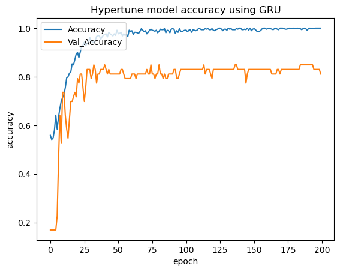

```python
# History of hypertune model for RNN
plt.plot(history_tune_gru.history['accuracy'])
plt.plot(history_tune_gru.history['val_accuracy'])
plt.title('Hypertune model accuracy using GRU')
plt.ylabel('accuracy')
plt.xlabel('epoch')
plt.legend(['Accuracy', 'Val_Accuracy'], loc='upper left')
plt.show()
```

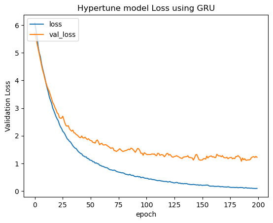

```python
# History of hypertune model for RNN
plt.plot(history_tune_gru.history['loss'])
plt.plot(history_tune_gru.history['val_loss'])
plt.title('Hypertune model Loss using GRU')
plt.ylabel('Validation Loss')
plt.xlabel('epoch')
plt.legend(['loss', 'val_loss'], loc='upper left')
plt.show()
```

```python
scores = model_tune_gru.evaluate(X_test, y_test)
print(f"\n Accuracy: {round(scores[1]*100, 2)}%")
```

```
 Accuracy: 86.26%
```

GRU have a higher accuracy than LSTM. Thus, use GRU

# 4) Model Evaluation

```python
from keras.utils.vis_utils import plot_model
from sklearn.metrics import classification_report
```

### Use to save the model

```python
model_tune_gru.save("model_RNN_partB.h5")
```

```python
model_tune_gru.save_weights("model_RNN_partB_weights.h5")
```

```python
model_tune_gru_loaded = tf.keras.models.load_model("model_RNN_partB.h5")
```

```python
scores = model_tune_gru_loaded.evaluate(X_test, y_test)

print(f"\n Accuracy: {round(scores[1]*100, 2)}%")
```

```
 Accuracy: 86.26%
```

```python
# Predict classes for the test set
y_pred = model_tune_gru_loaded.predict(X_test)

# Convert predicted probabilities to class labels
y_pred_class = np.argmax(y_pred, axis=1)
```

## i) Classification report

```python
# Print classification report
print("\nClassification Report:")
print(classification_report(y_test.argmax(axis=1), y_pred_class))
```

```
Classification Report:
              precision    recall  f1-score   support

           0       0.77      0.73      0.75        37
           1       0.90      0.91      0.91        94

    accuracy                           0.86       131
   macro avg       0.83      0.82      0.83       131
weighted avg       0.86      0.86      0.86       131
```

## ii) Visualise model

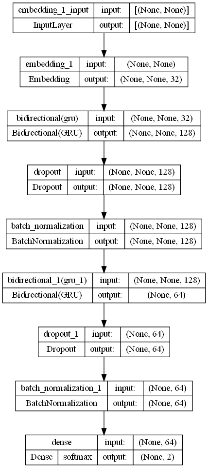

```python
plot_model(model_tune_gru_loaded, show_shapes=True, expand_nested=True, show_layer_activations=True, show_layer_names=True)
```